# IS 362 Final Project

### Population Data

```python
household_population = df2.groupby(['County_name'])[['Households_estimate_total', 'Families_estimate_total',
                                                     'Married_couple_families_estimate_total',
                                                     'Nonfamily_households_estimate_total']].sum()
household_population
```

| County_name | Households_estimate_total | Families_estimate_total | Married_couple_families_estimate_total | Nonfamily_households_estimate_total |
| --- | --- | --- | --- | --- |
| Albany County, New York | 125329 | 69122 | 49765.0 | 56207 |
| Bronx County, New York | 498539 | 331774 | 143169.0 | 166765 |
| Broome County, New York | 76957 | 46264 | 34412.0 | 30693 |
| Cattaraugus County, New York | 31409 | 19505 | 13993.0 | 11904 |
| Cayuga County, New York | 30966 | 18539 | 13311.0 | 12427 |
| Chautauqua County, New York | 51705 | 31199 | 24220.0 | 20506 |
| Chemung County, New York | 34418 | 21203 | 0.0 | 13215 |
| Clinton County, New York | 30624 | 20266 | 0.0 | 10358 |
| Dutchess County, New York | 108200 | 71176 | 53519.0 | 37024 |
| Erie County, New York | 380473 | 222109 | 155486.0 | 158364 |
| Jefferson County, New York | 41415 | 28174 | 21072.0 | 13241 |
| Kings County, New York | 941871 | 575987 | 348404.0 | 365884 |
| Livingston County, New York | 23904 | 14255 | 0.0 | 9649 |
| Madison County, New York | 25612 | 15782 | 0.0 | 9830 |
| Monroe County, New York | 299224 | 179894 | 124925.0 | 119330 |
| Nassau County, New York | 440785 | 337008 | 268693.0 | 103777 |
| New York County, New York | 748293 | 315379 | 213998.0 | 432914 |
| Niagara County, New York | 86786 | 54186 | 38684.0 | 32600 |
| Oneida County, New York | 87929 | 55064 | 39305.0 | 32865 |
| Onondaga County, New York | 182984 | 109911 | 79651.0 | 73073 |
| Ontario County, New York | 45187 | 29197 | 0.0 | 15990 |
| Orange County, New York | 124365 | 86063 | 66990.0 | 38302 |
| Oswego County, New York | 44633 | 29386 | 21300.0 | 15247 |
| Putnam County, New York | 34762 | 25936 | 0.0 | 8826 |
| Queens County, New York | 761819 | 505823 | 340611.0 | 255996 |
| Rensselaer County, New York | 62816 | 37775 | 27188.0 | 25041 |
| Richmond County, New York | 164289 | 121766 | 90779.0 | 42523 |
| Rockland County, New York | 99257 | 72925 | 59470.0 | 26332 |
| Saratoga County, New York | 93703 | 60786 | 47999.0 | 32917 |
| Schenectady County, New York | 48720 | 28959 | 0.0 | 19761 |
| St. Lawrence County, New York | 40479 | 26548 | 18412.0 | 13931 |
| Steuben County, New York | 38458 | 25434 | 18334.0 | 13024 |
| Suffolk County, New York | 474311 | 349115 | 272856.0 | 125196 |
| Sullivan County, New York | 25031 | 16346 | 0.0 | 8685 |
| Tompkins County, New York | 37683 | 20315 | 0.0 | 17368 |
| Ulster County, New York | 68298 | 41957 | 29890.0 | 26341 |
| Warren County, New York | 28841 | 17013 | 0.0 | 11828 |
| Wayne County, New York | 37496 | 26178 | 0.0 | 11318 |
| Westchester County, New York | 342216 | 235177 | 175861.0 | 107039 |

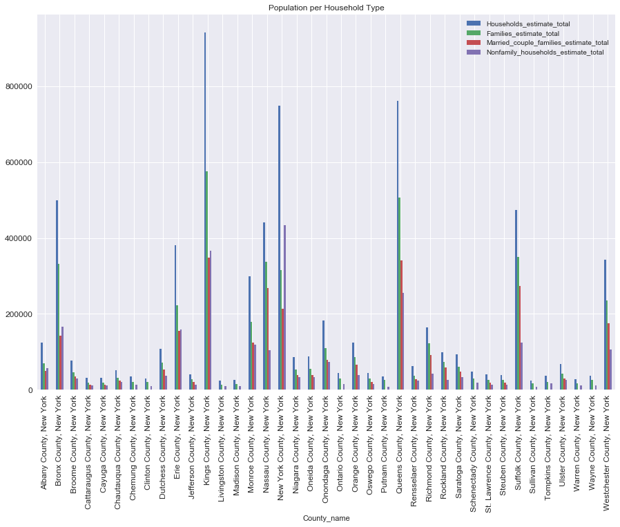

```python
household_population.plot(kind='bar', title ="Population per Household Type", figsize=(15, 10), legend=True, fontsize=12)
ax.set_xlabel("County", fontsize=12)
ax.set_ylabel("Population", fontsize=12)
plt.show()
```

## Sort Data by Household Type

```python
sorted_by_households = household_population.sort_values(by=['Households_estimate_total'])
sorted_by_households
```

| County_name | Households_estimate_total | Families_estimate_total | Married_couple_families_estimate_total | Nonfamily_households_estimate_total |
| --- | --- | --- | --- | --- |
| Livingston County, New York | 23904 | 14255 | 0.0 | 9649 |
| Sullivan County, New York | 25031 | 16346 | 0.0 | 8685 |
| Madison County, New York | 25612 | 15782 | 0.0 | 9830 |
| Warren County, New York | 28841 | 17013 | 0.0 | 11828 |
| Clinton County, New York | 30624 | 20266 | 0.0 | 10358 |
| Cayuga County, New York | 30966 | 18539 | 13311.0 | 12427 |
| Cattaraugus County, New York | 31409 | 19505 | 13993.0 | 11904 |
| Chemung County, New York | 34418 | 21203 | 0.0 | 13215 |
| Putnam County, New York | 34762 | 25936 | 0.0 | 8826 |
| Wayne County, New York | 37496 | 26178 | 0.0 | 11318 |
| Tompkins County, New York | 37683 | 20315 | 0.0 | 17368 |
| Steuben County, New York | 38458 | 25434 | 18334.0 | 13024 |
| St. Lawrence County, New York | 40479 | 26548 | 18412.0 | 13931 |
| Jefferson County, New York | 41415 | 28174 | 21072.0 | 13241 |
| Oswego County, New York | 44633 | 29386 | 21300.0 | 15247 |
| Ontario County, New York | 45187 | 29197 | 0.0 | 15990 |
| Schenectady County, New York | 48720 | 28959 | 0.0 | 19761 |
| Chautauqua County, New York | 51705 | 31199 | 24220.0 | 20506 |
| Rensselaer County, New York | 62816 | 37775 | 27188.0 | 25041 |
| Ulster County, New York | 68298 | 41957 | 29890.0 | 26341 |
| Broome County, New York | 76957 | 46264 | 34412.0 | 30693 |
| Niagara County, New York | 86786 | 54186 | 38684.0 | 32600 |
| Oneida County, New York | 87929 | 55064 | 39305.0 | 32865 |
| Saratoga County, New York | 93703 | 60786 | 47999.0 | 32917 |
| Rockland County, New York | 99257 | 72925 | 59470.0 | 26332 |
| Dutchess County, New York | 108200 | 71176 | 53519.0 | 37024 |
| Orange County, New York | 124365 | 86063 | 66990.0 | 38302 |
| Albany County, New York | 125329 | 69122 | 49765.0 | 56207 |
| Richmond County, New York | 164289 | 121766 | 90779.0 | 42523 |
| Onondaga County, New York | 182984 | 109911 | 79651.0 | 73073 |
| Monroe County, New York | 299224 | 179894 | 124925.0 | 119330 |
| Westchester County, New York | 342216 | 235177 | 175861.0 | 107039 |
| Erie County, New York | 380473 | 222109 | 155486.0 | 158364 |
| Nassau County, New York | 440785 | 337008 | 268693.0 | 103777 |
| Suffolk County, New York | 474311 | 349115 | 272856.0 | 125196 |
| Bronx County, New York | 498539 | 331774 | 143169.0 | 166765 |
| New York County, New York | 748293 | 315379 | 213998.0 | 432914 |
| Queens County, New York | 761819 | 505823 | 340611.0 | 255996 |
| Kings County, New York | 941871 | 575987 | 348404.0 | 365884 |

### Plot Sorted Data of Household Type

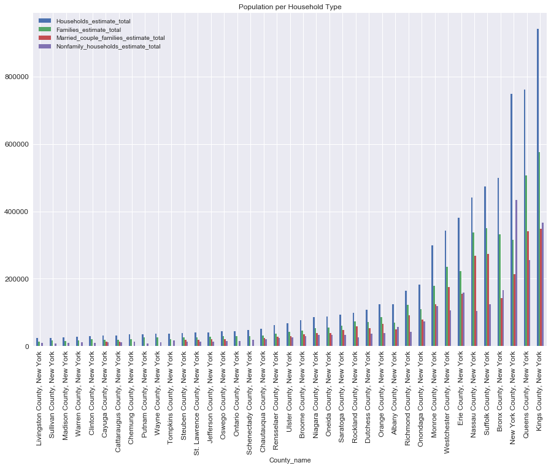

```python
sorted_by_households.plot(kind='bar', title ="Population per Household Type", figsize=(15, 10), legend=True, fontsize=12)
ax.set_xlabel("County", fontsize=12)
ax.set_ylabel("Population", fontsize=12)
plt.show()
```

### Low Income Families Data Plot

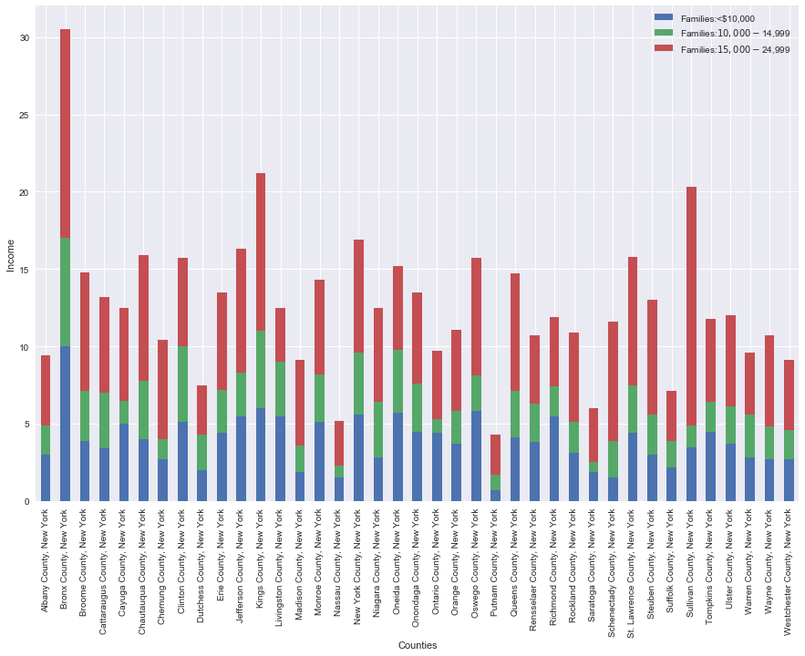

```python
counties = df2.groupby(['County_name'])[['Families:<$10,000', 'Families:$10,000-$14,999', 'Families:$15,000-$24,999']].sum()
my_plot = counties.plot(kind='bar', stacked=True, figsize=(15, 10))
my_plot.set_xlabel('Counties')
my_plot.set_ylabel('Income')
my_plot.legend(['Families:<$10,000', 'Families:$10,000-$14,999', 'Families:$15,000-$24,999'])
```

```python
counties
```

| County_name | Families:<$10,000 | Families:$10,000-$14,999 | Families:$15,000-$24,999 |
| --- | --- | --- | --- |
| Albany County, New York | 3.0 | 1.9 | 4.5 |
| Bronx County, New York | 10.0 | 7.0 | 13.5 |
| Broome County, New York | 3.9 | 3.2 | 7.7 |
| Cattaraugus County, New York | 3.4 | 3.6 | 6.2 |
| Cayuga County, New York | 5.0 | 1.5 | 6.0 |
| Chautauqua County, New York | 4.0 | 3.8 | 8.1 |
| Chemung County, New York | 2.7 | 1.3 | 6.4 |
| Clinton County, New York | 5.1 | 4.9 | 5.7 |
| Dutchess County, New York | 2.0 | 2.3 | 3.2 |
| Erie County, New York | 4.4 | 2.8 | 6.3 |
| Jefferson County, New York | 5.5 | 2.8 | 8.0 |
| Kings County, New York | 6.0 | 5.0 | 10.2 |
| Livingston County, New York | 5.5 | 3.5 | 3.5 |
| Madison County, New York | 1.9 | 1.7 | 5.5 |
| Monroe County, New York | 5.1 | 3.1 | 6.1 |
| Nassau County, New York | 1.5 | 0.8 | 2.9 |
| New York County, New York | 5.6 | 4.0 | 7.3 |
| Niagara County, New York | 2.8 | 3.6 | 6.1 |
| Oneida County, New York | 5.7 | 4.1 | 5.4 |
| Onondaga County, New York | 4.5 | 3.1 | 5.9 |
| Ontario County, New York | 4.4 | 0.9 | 4.4 |
| Orange County, New York | 3.7 | 2.1 | 5.3 |
| Oswego County, New York | 5.8 | 2.3 | 7.6 |
| Putnam County, New York | 0.7 | 1.0 | 2.6 |
| Queens County, New York | 4.1 | 3.0 | 7.6 |
| Rensselaer County, New York | 3.8 | 2.5 | 4.4 |
| Richmond County, New York | 5.5 | 1.9 | 4.5 |
| Rockland County, New York | 3.1 | 2.0 | 5.8 |
| Saratoga County, New York | 1.9 | 0.6 | 3.5 |
| Schenectady County, New York | 1.5 | 2.4 | 7.7 |
| St. Lawrence County, New York | 4.4 | 3.1 | 8.3 |
| Steuben County, New York | 3.0 | 2.6 | 7.4 |
| Suffolk County, New York | 2.2 | 1.7 | 3.2 |
| Sullivan County, New York | 3.5 | 1.4 | 15.4 |
| Tompkins County, New York | 4.5 | 1.9 | 5.4 |
| Ulster County, New York | 3.7 | 2.4 | 5.9 |
| Warren County, New York | 2.8 | 2.8 | 4.0 |
| Wayne County, New York | 2.7 | 2.1 | 5.9 |
| Westchester County, New York | 2.7 | 1.9 | 4.5 |

```python
print(list(df2.columns))
```

```
['County code', 'County_name', 'Households_estimate_total', 'Families_estimate_total', 'Married_couple_families_estimate_total', 'Nonfamily_households_estimate_total', 'Households:<$10,000', 'Families:<$10,000', 'Married-couple_families:<$10,000', 'Nonfamily_households:<$10,000', 'Households:$10,000…
```

## Families Household

For this section, I want to compare the income of each counties compared to its birth rates. I've decided to look more into the "families" household for this analysis. I will combine income levels in relation to the income classes:

1. **Low Income Class: Below 10,000 to 24,000**
2. **Lower Middle Class: 25,000 - 49,000**
3. **Middle Middle Class: 50,000 - 99,999**
4. **Upper Middle Class: 100,000 or more**

```python
sum_df2 = df2
sum_df2
```

|  | County code | County_name | Households_estimate_total | Families_estimate_total | Married_couple_families_estimate_total | Nonfamily_households_estimate_total | Households:<$10,000 | Families:<$10,000 | Married-couple_families:<$10,000 | Nonfamily_households:<$10,000 | ... | Married-couple_families:$200,000_or_more | Nonfamily_households:$200,000_or_more | Households:Median_income | Families:Median_income | Married-couple_families:Median_income | Nonfamily_households:Median_income | Households:Mean_income | Families:Mean_income | Married-couple_households:Mean_income | Nonfamily_households:Mean_income |
| --- | --- | --- | --- | --- | --- | --- | --- | --- | --- | --- | --- | --- | --- | --- | --- | --- | --- | --- | --- | --- | --- |
| 0 | 36001 | Albany County, New York | 125329 | 69122 | 49765.0 | 56207 | 6.2 | 3.0 | 0.8 | 10.8 | ... | 14.5 | 1.9 | 61754 | 85897 | 107425 | 40299 | 83464 | 106202 | N | 52871 |
| 1 | 36005 | Bronx County, New York | 498539 | 331774 | 143169.0 | 166765 | 14.4 | 10.0 | 2.6 | 25.8 | ... | 4.5 | 0.7 | 37525 | 42602 | 61249 | 23673 | 53466 | 59196 | 79371 | 36561 |
| 2 | 36007 | Broome County, New York | 76957 | 46264 | 34412.0 | 30693 | 6.5 | 3.9 | 0.9 | 11.5 | ... | 5.6 | 0.8 | 50463 | 63692 | 75885 | 26920 | 67239 | 82375 | N | 41473 |
| 3 | 36009 | Cattaraugus County, New York | 31409 | 19505 | 13993.0 | 11904 | 7.9 | 3.4 | 0.2 | 16.6 | ... | 1.9 | 0.5 | 46842 | 57699 | 72245 | 25977 | 57722 | 69266 | N | 36092 |
| 4 | 36011 | Cayuga County, New York | 30966 | 18539 | 13311.0 | 12427 | 6.0 | 5.0 | 1.2 | 9.4 | ... | 4.0 | 1.2 | 54995 | 66121 | 77689 | 36164 | 68575 | 76794 | N | 51709 |
| 5 | 36013 | Chautauqua County, New York | 51705 | 31199 | 24220.0 | 20506 | 7.5 | 4.0 | 1.4 | 14.1 | ... | 1.1 | 1.3 | 42204 | 56959 | 65584 | 24519 | 55539 | 66524 | N | 37461 |
| 6 | 36015 | Chemung County, New York | 34418 | 21203 | 0.0 | 13215 | 7.5 | 2.7 | N | 15.8 | ... | N | 1.4 | 51269 | 69651 | 82609 | 23150 | 67332 | 82566 | N | 39057 |
| 7 | 36019 | Clinton County, New York | 30624 | 20266 | 0.0 | 10358 | 5.7 | 5.1 | N | 10.9 | ... | N | 0.0 | 55316 | 64266 | 72724 | 32279 | 65214 | 73337 | N | 43961 |
| 8 | 36027 | Dutchess County, New York | 108200 | 71176 | 53519.0 | 37024 | 3.7 | 2.0 | 0.7 | 7.7 | ... | 14.9 | 3.3 | 74115 | 91993 | 110525 | 42124 | 99958 | 117569 | N | 62794 |
| 9 | 36029 | Erie County, New York | 380473 | 222109 | 155486.0 | 158364 | 8.2 | 4.4 | 1.9 | 14.3 | ... | 8.9 | 1.3 | 54246 | 73253 | 90175 | 31841 | 73544 | 92176 | 108991 | 45212 |
| 10 | 36045 | Jefferson County, New York | 41415 | 28174 | 21072.0 | 13241 | 8.4 | 5.5 | 1.9 | 17.6 | ... | 2.5 | 1.5 | 45624 | 55102 | 67431 | 27975 | 61225 | 68344 | N | 42343 |
| 11 | 36047 | Kings County, New York | 941871 | 575987 | 348404.0 | 365884 | 10.7 | 6.0 | 2.5 | 18.9 | ... | 13.5 | 4.3 | 55150 | 61989 | 79148 | 41030 | 83115 | 92770 | 114784 | 62717 |
| 12 | 36051 | Livingston County, New York | 23904 | 14255 | 0.0 | 9649 | 7.0 | 5.5 | N | 9.6 | ... | N | 0.0 | 53121 | 65702 | 73527 | 35027 | 61229 | 74351 | N | 39391 |
| 13 | 36053 | Madison County, New York | 25612 | 15782 | 0.0 | 9830 | 4.8 | 1.9 | N | 9.7 | ... | N | 1.7 | 60630 | 83422 | 95233 | 31954 | 76630 | 95147 | N | 44304 |
| 14 | 36055 | Monroe County, New York | 299224 | 179894 | 124925.0 | 119330 | 8.3 | 5.1 | 1.7 | 13.7 | ... | 9.1 | 1.2 | 54492 | 73088 | 93838 | 33895 | 74700 | 91518 | 111182 | 46987 |
| 15 | 36059 | Nassau County, New York | 440785 | 337008 | 268693.0 | 103777 | 3.0 | 1.5 | 0.6 | 8.6 | ... | 27.7 | 4.4 | 105870 | 125601 | 139786 | 43643 | 139034 | 158896 | 174729 | 67061 |
| 16 | 36061 | New York County, New York | 748293 | 315379 | 213998.0 | 432914 | 9.4 | 5.6 | 2.2 | 12.6 | ... | 41.2 | 13.4 | 77559 | 99195 | 157287 | 67843 | 143741 | 195026 | 257569 | 104969 |
| 17 | 36063 | Niagara County, New York | 86786 | 54186 | 38684.0 | 32600 | 6.6 | 2.8 | 0.5 | 13.1 | ... | 4.1 | 0.7 | 50233 | 68775 | 86490 | 31352 | 65869 | 79627 | N | 39581 |
| 18 | 36065 | Oneida County, New York | 87929 | 55064 | 39305.0 | 32865 | 7.7 | 5.7 | 2.3 | 12.9 | ... | 6.0 | 0.6 | 52996 | 67107 | 77268 | 30846 | 68695 | 82581 | 96525 | 41405 |
| 19 | 36067 | Onondaga County, New York | 182984 | 109911 | 79651.0 | 73073 | 7.8 | 4.5 | 1.9 | 13.7 | ... | 8.1 | 1.6 | 56991 | 76453 | 91710 | 33844 | 76174 | 93616 | 110749 | 46823 |
| 20 | 36069 | Ontario County, New York | 45187 | 29197 | 0.0 | 15990 | 3.8 | 4.4 | N | 6.6 | ... | N | 0.8 | 57448 | 76497 | 92546 | 35712 | 78032 | 95296 | N | 41661 |
| 21 | 36071 | Orange County, New York | 124365 | 86063 | 66990.0 | 38302 | 5.6 | 3.7 | 2.1 | 10.1 | ... | 12.4 | 3.1 | 73025 | 89797 | 105732 | 38069 | 91061 | 104983 | 118359 | 56367 |
| 22 | 36075 | Oswego County, New York | 44633 | 29386 | 21300.0 | 15247 | 6.5 | 5.8 | 2.0 | 10.3 | ... | 3.7 | 1.5 | 53562 | 63639 | 76014 | 33491 | 65090 | 74438 | N | 43404 |
| 23 | 36079 | Putnam County, New York | 34762 | 25936 | 0.0 | 8826 | 0.8 | 0.7 | N | 1.1 | ... | N | 3.6 | 96992 | 115978 | 127603 | 50000 | 122979 | 140021 | N | 70562 |
| 24 | 36081 | Queens County, New York | 761819 | 505823 | 340611.0 | 255996 | 6.9 | 4.1 | 2.3 | 13.4 | ... | 8.9 | 2.4 | 62207 | 70538 | 81299 | 42671 | 81379 | 89303 | 100292 | 59597 |
| 25 | 36083 | Rensselaer County, New York | 62816 | 37775 | 27188.0 | 25041 | 4.5 | 3.8 | 1.1 | 7.0 | ... | 9.1 | 1.8 | 65965 | 83174 | 103303 | 37377 | 80856 | 96807 | N | 50305 |
| 26 | 36085 | Richmond County, New York | 164289 | 121766 | 90779.0 | 42523 | 9.2 | 5.5 | 2.1 | 21.1 | ... | 14.6 | 1.2 | 77197 | 93093 | 106673 | 34500 | 95481 | 110238 | 125128 | 47645 |
| 27 | 36087 | Rockland County, New York | 99257 | 72925 | 59470.0 | 26332 | 4.0 | 3.1 | 2.4 | 6.5 | ... | 22.2 | 5.5 | 85515 | 101100 | 112463 | 51545 | 116116 | 129729 | N | 71484 |
| 28 | 36089 | St. Lawrence County, New York | 40479 | 26548 | 18412.0 | 13931 | 6.5 | 4.4 | 2.7 | 12.4 | ... | 3.6 | 1.6 | 51592 | 60475 | 72624 | 28774 | 64088 | 71713 | N | 45696 |
| 29 | 36091 | Saratoga County, New York | 93703 | 60786 | 47999.0 | 32917 | 4.0 | 1.9 | 0.5 | 8.3 | ... | 13.9 | 2.5 | 76097 | 92050 | 103409 | 45562 | 99966 | 118985 | N | 59954 |
| 30 | 36093 | Schenectady County, New York | 48720 | 28959 | 0.0 | 19761 | 4.0 | 1.5 | N | 8.2 | ... | N | 0.8 | 58331 | 76279 | 89212 | 34293 | 75564 | 92631 | N | 47989 |
| 31 | 36101 | Steuben County, New York | 38458 | 25434 | 18334.0 | 13024 | 4.2 | 3.0 | 0.4 | 8.7 | ... | 4.0 | 1.7 | 50575 | 59901 | 71363 | 31958 | 69894 | 74981 | N | 56139 |
| 32 | 36103 | Suffolk County, New York | 474311 | 349115 | 272856.0 | 125196 | 3.5 | 2.2 | 0.8 | 8.8 | ... | 19.6 | 4.3 | 92933 | 107747 | 122043 | 47270 | 118609 | 133523 | 147904 | 68706 |
| 33 | 36105 | Sullivan County, New York | 25031 | 16346 | 0.0 | 8685 | 6.7 | 3.5 | N | 12.9 | ... | N | 3.4 | 50652 | 70403 | 83333 | 29474 | 76471 | 92383 | N | 43934 |
| 34 | 36109 | Tompkins County, New York | 37683 | 20315 | 0.0 | 17368 | 11.8 | 4.5 | N | 20.6 | ... | N | 2.1 | 56349 | 78948 | 91513 | 31051 | 73644 | 96948 | N | 42235 |
| 35 | 36111 | Ulster County, New York | 68298 | 41957 | 29890.0 | 26341 | 4.9 | 3.7 | 1.9 | 7.2 | ... | 13.4 | 1.1 | 62790 | 78407 | 95033 | 31734 | 82176 | 100833 | 117805 | 48383 |
| 36 | 36113 | Warren County, New York | 28841 | 17013 | 0.0 | 11828 | 5.0 | 2.8 | N | 9.3 | ... | N | 1.1 | 58061 | 71433 | 85905 | 35239 | 75717 | 91408 | N | 49656 |
| 37 | 36117 | Wayne County, New York | 37496 | 26178 | 0.0 | 11318 | 3.5 | 2.7 | N | 6.7 | ... | N | 1.3 | 59538 | 64662 | 75681 | 36527 | 70422 | 75563 | N | 51847 |
| 38 | 36119 | Westchester County, New York | 342216 | 235177 | 175861.0 | 107039 | 5.4 | 2.7 | 1.4 | 11.8 | ... | 32.1 | 4.6 | 89709 | 113190 | 138971 | 47468 | 141104 | 170464 | N | 72004 |

39 rows × 54 columns

### Families Low Income Data

```python
sum_df2['Families:Low_Income'] = sum_df2['Families:<$10,000'] + sum_df2['Families:$10,000-$14,999'] + \
                                 sum_df2['Families:$15,000-$24,999']
sum_df2['Families:Low_Income']
```

```
0      9.4
1     30.5
2     14.8
3     13.2
4     12.5
5     15.9
6     10.4
7     15.7
8      7.5
9     13.5
10    16.3
11    21.2
12    12.5
13     9.1
14    14.3
```

[output cut: 25 more lines]

### Families Lower Middle Class Income Data

```python
sum_df2['Families:Lowermiddle_Income'] = sum_df2['Families:$25,000-$34,999'] + sum_df2['Families:$35,000-$49,999']
sum_df2['Families:Lowermiddle_Income']
```

```
0     17.3
1     25.9
2     22.2
3     27.4
4     24.8
5     26.2
6     23.7
7     19.9
8     15.6
9     18.8
10    29.8
11    20.8
12    17.7
13    17.2
14    19.1
```

[output cut: 25 more lines]

### Families Middle Middle Class Income Data

```python
sum_df2['Families:Middlemiddle_Income'] = sum_df2['Families:$50,000-$74,999'] + sum_df2['Families:$75,000-$99,999']
sum_df2['Families:Middlemiddle_Income']
```

```
0     31.0
1     26.7
2     36.7
3     38.1
4     36.8
5     38.0
6     38.4
7     41.7
8     30.0
9     34.4
10    31.1
11    27.4
12    46.5
13    33.8
14    33.0
```

[output cut: 25 more lines]

### Families Upper Middle Class Income Data

```python
sum_df2['Families:Uppermiddle_Income'] = sum_df2['Families:$100,000-$149,999'] + sum_df2['Families:$150,000-$199,999'] + \
                                         sum_df2['Families:$200,000_or_more']
sum_df2['Families:Uppermiddle_Income']
```

```
0     42.3
1     16.9
2     26.2
3     21.3
4     26.0
5     19.9
6     27.6
7     22.8
8     46.8
9     33.3
10    22.7
11    30.8
12    23.2
13    39.9
14    33.5
```

[output cut: 25 more lines]

### Visualizing the Income Class

```python
families = sum_df2.groupby(['County_name'])[['Families:Low_Income', 'Families:Lowermiddle_Income',
                                            'Families:Middlemiddle_Income', 'Families:Uppermiddle_Income']].sum()
```

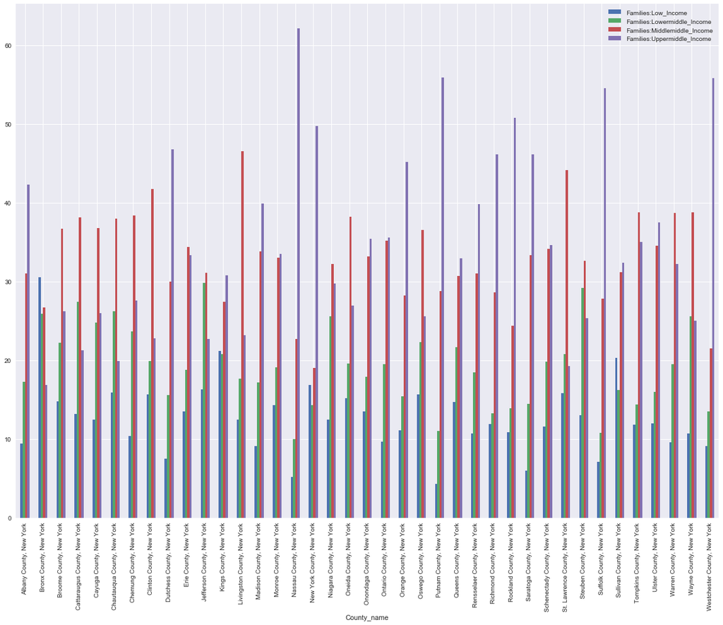

```python
families.plot(kind='bar', figsize=(20, 15))
```

```python
families_sorted = families.sort_values(by=['Families:Low_Income'])
families_sorted
```

| County_name | Families:Low_Income | Families:Lowermiddle_Income | Families:Middlemiddle_Income | Families:Uppermiddle_Income |
| --- | --- | --- | --- | --- |
| Putnam County, New York | 4.3 | 11.0 | 28.8 | 55.9 |
| Nassau County, New York | 5.2 | 10.0 | 22.7 | 62.1 |
| Saratoga County, New York | 6.0 | 14.5 | 33.3 | 46.1 |
| Suffolk County, New York | 7.1 | 10.8 | 27.8 | 54.5 |
| Dutchess County, New York | 7.5 | 15.6 | 30.0 | 46.8 |
| Westchester County, New York | 9.1 | 13.5 | 21.5 | 55.8 |
| Madison County, New York | 9.1 | 17.2 | 33.8 | 39.9 |
| Albany County, New York | 9.4 | 17.3 | 31.0 | 42.3 |
| Warren County, New York | 9.6 | 19.5 | 38.7 | 32.2 |
| Ontario County, New York | 9.7 | 19.5 | 35.2 | 35.6 |
| Chemung County, New York | 10.4 | 23.7 | 38.4 | 27.6 |
| Rensselaer County, New York | 10.7 | 18.5 | 31.0 | 39.8 |
| Wayne County, New York | 10.7 | 25.6 | 38.8 | 25.0 |
| Rockland County, New York | 10.9 | 13.9 | 24.4 | 50.8 |
| Orange County, New York | 11.1 | 15.4 | 28.2 | 45.2 |
| Schenectady County, New York | 11.6 | 19.8 | 34.1 | 34.6 |
| Tompkins County, New York | 11.8 | 14.4 | 38.8 | 35.0 |
| Richmond County, New York | 11.9 | 13.3 | 28.6 | 46.1 |
| Ulster County, New York | 12.0 | 16.0 | 34.5 | 37.5 |
| Livingston County, New York | 12.5 | 17.7 | 46.5 | 23.2 |
| Cayuga County, New York | 12.5 | 24.8 | 36.8 | 26.0 |
| Niagara County, New York | 12.5 | 25.6 | 32.2 | 29.7 |
| Steuben County, New York | 13.0 | 29.2 | 32.6 | 25.3 |
| Cattaraugus County, New York | 13.2 | 27.4 | 38.1 | 21.3 |
| Erie County, New York | 13.5 | 18.8 | 34.4 | 33.3 |
| Onondaga County, New York | 13.5 | 17.9 | 33.2 | 35.4 |
| Monroe County, New York | 14.3 | 19.1 | 33.0 | 33.5 |
| Queens County, New York | 14.7 | 21.7 | 30.7 | 32.9 |
| Broome County, New York | 14.8 | 22.2 | 36.7 | 26.2 |
| Oneida County, New York | 15.2 | 19.6 | 38.2 | 26.9 |
| Oswego County, New York | 15.7 | 22.3 | 36.5 | 25.6 |
| Clinton County, New York | 15.7 | 19.9 | 41.7 | 22.8 |
| St. Lawrence County, New York | 15.8 | 20.8 | 44.1 | 19.3 |
| Chautauqua County, New York | 15.9 | 26.2 | 38.0 | 19.9 |
| Jefferson County, New York | 16.3 | 29.8 | 31.1 | 22.7 |
| New York County, New York | 16.9 | 14.3 | 19.0 | 49.7 |
| Sullivan County, New York | 20.3 | 16.2 | 31.2 | 32.4 |
| Kings County, New York | 21.2 | 20.8 | 27.4 | 30.8 |
| Bronx County, New York | 30.5 | 25.9 | 26.7 | 16.9 |